## Rare variant arthesclerosis

### Introduction

#### Arthesclerosis is a complex disease with complicated eitology

#### Rare variants have been implicated in different complex studies. Modern genomics technology such as sequencing uncover unprecidented amount of data.

#### Hicap and other technology connects the non functional regions with promoter and enhancer

#### n the current study we have used the rare variants from population study of swedish population. And observed the profile of rare and low frequency variants in interaction data from arthescloris patients. The goal was to annotate these promoter mediated enhaver regions with different funcitional marks and observe whethter there is enrichment of any of these DNA elements enriched in any of the regions

## Material and methods

### Data acquistion

Annotation data from chipseq was used. I access the dataset dated on 30th september and download individual files from chipseq atlas and downloaded the chipseq peaks for H3Kmeth and H327Ac dataset as Histone modification markers and transcription factor binding sites for corresponding peaks. The main objective of this practise was to find the individual profile of each enhancer and calcuate the enrichment score of each datatset

### Defination of Rare and low frequncy variant in the population

The variants from the swedish ppluation was classified into theree seperate catogories i.e Rare, Low frequncy and common based on the allele frequncy in the population THe variant classification were on the frequency such that variant with MAF>0.05 were classified as “Common”, Low frequency with 0.05 < MAF < 0.01, Rare variants < 0.01. However in the rare frequncy variants wer have removed that private variants that were present within one individual either in homozygous or heterozygous condition.

### Python script

Customized python script was developed for each tasks and following this a pipleline scheme of these scripts were run in both low frequency and rare varaints .

## Results

### Number of Rare, Common and low frequency alleles in Swedgen population and number in the enhancer region of genome

The preprocessed promoter-enhancer list was contained 33,323 unique enhancers regions in Bicuspid aortic valve (BAV cells. The data contains of promoter regions and corresponding enhancer regions of 2 replicates from BAV cell. We found on average of 20.38 and 13.93 interaction enhacers change in replicate1 and replicate2 respectivley. As shown in figure 1, we identified distribution of different enhancer length.

[output not shown]

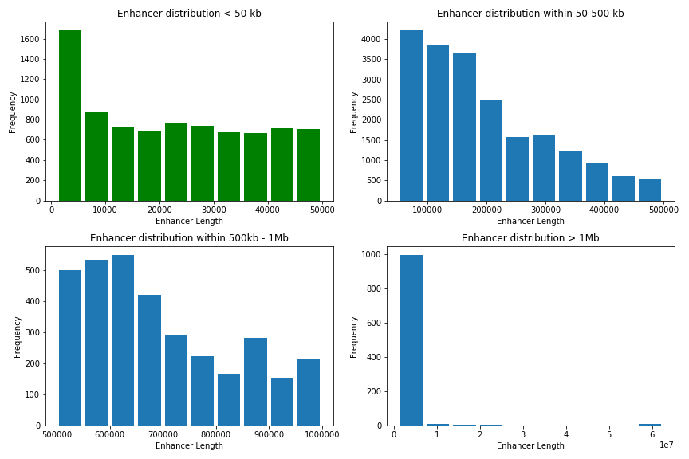

figures 1

This length distribution depicts that most of our putative enhancers are within the range of 50-1Mb base pairs which is in par with the Hi-C methods

| Variant class | Enhancer with variants | Total variants type |
| --- | --- | --- |
| Common | 22055 | 56891 |
| Low Frequency | 14403 | 24049 |
| Rare | 22144 | 47281 |

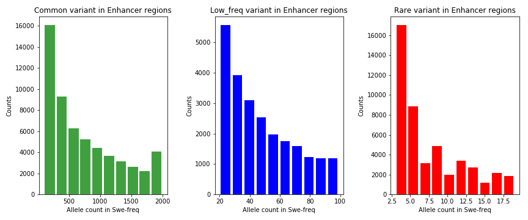

figures 2

### Status of non coding functional elememts of varaints embedded enhancer regions

[output not shown]

[figure not shown]

figures 3

From the above chart, it can been said that we have at least one of functional markers in about (5087/22055) 23% of putative enhacer in all classes of variants. However, it has to be considered that we took into consideration one of cellline and these are the markers specific to cell type. Most intersting , we still find at least 1000 putatively, functional enhancers in all classes in all. It would be interesting to see these functional enhancer regions and dig into Rare and Low frequency varaints in these region. More intersting, it would be interesting if any of these varaints are earlier implicated in any arthesceloris heart diseases. Furthermore, these are result only from overlpaaing with one dataset. This data has to be randomized and overlapped so as to find the putative p-values to our non coding functional elements.

### Discussion

High enrichment of rare variants in putative enhancer with allele count less than 5

Based on the defination of different enhancer such as H327ac and H3Kme1 we didnt found high enrichment, it might be as we only looked into one type of cell type which doesn’t matched the real primary cell type.